# Desigualdad de Oportunidad en México

Análisis con ESRU-EMOVI 2023

Eduardo

24 de January de 2026

# Resumen Ejecutivo

Este estudio analiza la **Desigualdad de Oportunidad (IOp)** en México utilizando datos de la Encuesta ESRU-EMOVI 2023. La pregunta central es:

> **¿Qué proporción de la desigualdad de ingresos se debe a circunstancias fuera del control individual?**

## Hallazgo Principal

Resultados principales de IOp

| Métrica | Valor | Interpretación |
| --- | --- | --- |
| IOp (Random Forest) | 52.6% | Estimación principal |
| IOp (XGBoost) | 53.5% | Con optimización de hiperparámetros |
| IOp (Árbol de Decisión) | 55.4% | Modelo interpretable |

**Conclusión:** Aproximadamente **52-55% de la desigualdad de ingresos** en México se debe a circunstancias fuera del control individual como la educación de los padres, el lugar de nacimiento y el sexo.

# 1. Introducción

## 1.1 ¿Qué es la Desigualdad de Oportunidad?

La **Desigualdad de Oportunidad (IOp)** mide qué proporción de la desigualdad total se debe a factores que las personas **no pueden controlar**, llamados **circunstancias**:

- Educación de los padres
- Ocupación de los padres
- Región donde creciste
- Sexo
- Etnicidad
- Si creciste en zona rural o urbana

Bajo el marco de **John Roemer**, la desigualdad que proviene de estas circunstancias se considera **injusta** o **éticamente inaceptable**.

## 1.2 Datos Utilizados

| Característica | Valor |
| --- | --- |
| Encuesta | ESRU-EMOVI |
| Año | 2023 |
| Observaciones totales | 17,843 |
| Casos completos para análisis | 13,164 |
| Variable de resultado | Ingreso per cápita del hogar |

# 2. Metodología

## 2.1 Marco Conceptual

Siguiendo a **Brunori et al. (2023)** y **Roemer (1998)**, utilizamos métodos de machine learning para:

1. **Particionar** la población en “tipos” basados en circunstancias
2. **Calcular** el ingreso promedio de cada tipo
3. **Medir** qué proporción de la desigualdad total se explica por las diferencias entre tipos

$$IOp =
\frac{Gini(\mu_{tipos})}{Gini(Y)}$$

Donde: - $Gini(\mu_{tipos})$ = Desigualdad entre los promedios de cada tipo - $Gini(Y)$ = Desigualdad total del ingreso

## 2.2 Variables de Circunstancias

[output not shown]

## 2.3 Modelos Utilizados

| Modelo | Propósito |
| --- | --- |
| **Árbol de Decisión** | Interpretabilidad - ver cómo se forman los tipos |
| **Random Forest** | Estimación robusta - promedio de 200 árboles |
| **Gradient Boosting** | Mayor poder predictivo |
| **XGBoost + SHAP** | Interpretabilidad avanzada |

# 3. Resultados

## 3.1 Estimaciones de IOp

Estimaciones de Desigualdad de Oportunidad

Modelo

IOp (Gini)

R²

N° Tipos

Árbol de Decisión

55.4%

28.3%

58

Random Forest

52.6%

25.9%

Gradient Boosting

56.8%

31.2%

XGBoost (optimizado)

53.5%

34.5%

Random Forest (CV 5-fold)

51.5%

25.8%

**Interpretación:** Todos los modelos coinciden en que aproximadamente **52-57%** de la desigualdad de ingresos se debe a circunstancias. El estimado principal (Random Forest) es **52.6%**.

## 3.2 Importancia de las Circunstancias

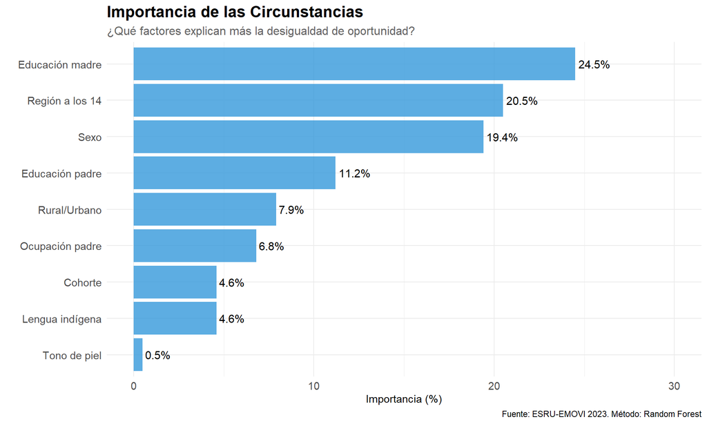

## 3.3 Ingreso Promedio por Circunstancia

[output not shown]

### 3.3.1 Por Educación de la Madre

[figure not shown]

[output not shown]

### 3.3.2 Por Educación del Padre

[figure not shown]

[output not shown]

### 3.3.3 Por Sexo

[figure not shown]

[output not shown]

### 3.3.4 Por Región a los 14 años

[figure not shown]

[output not shown]

### 3.3.5 Por Tipo de Localidad (Rural/Urbano)

[figure not shown]

[output not shown]

### 3.3.6 Por Ocupación del Padre

[figure not shown]

[output not shown]

### 3.3.7 Por Condición Indígena

[figure not shown]

[output not shown]

```
## No se pudieron calcular las brechas.
```

# 4. Visualización del Árbol de Decisión

El árbol de decisión muestra cómo las circunstancias dividen a la población en grupos con diferentes ingresos esperados.

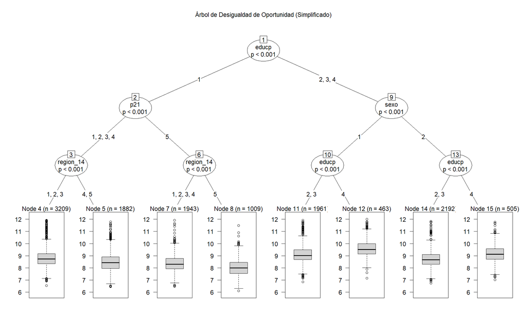

Árbol de decisión simplificado mostrando la partición en tipos

**Cómo leer el árbol:**

- Cada **nodo interno** muestra una variable y el criterio de división
- Cada **nodo terminal** (hoja) representa un “tipo” de personas con circunstancias similares
- Los **boxplots** muestran la distribución del log(ingreso) en cada tipo

# 5. Comparación con la Literatura

Comparación con estudios previos para México

| Estudio | Datos | IOp | Método |
| --- | --- | --- | --- |
| Este estudio (2023) | EMOVI 2023 | 52-57% | ctree/Random Forest/XGBoost |
| Monroy-Gómez-Franco (2023) | EMOVI 2017 | ≥48% | Conditional Inference Trees |
| Plassot et al. (2022) | EMOVI 2017 | 45-55% | Machine Learning |

Nuestros resultados son **consistentes** con la literatura previa. El ligero aumento en IOp (de ~48% a ~53%) podría reflejar cambios reales en la desigualdad de oportunidad entre 2017 y 2023, o diferencias metodológicas menores.

# 6. Conclusiones

## 6.2 Implicaciones de Política

Estos resultados sugieren que para reducir la desigualdad de oportunidad en México se necesitan políticas enfocadas en:

- **Educación**: Especialmente la educación de las mujeres (futuras madres)
- **Desarrollo regional**: Reducir las brechas entre regiones
- **Equidad de género**: Políticas para cerrar la brecha salarial
- **Primera infancia**: Intervenciones tempranas para nivelar el campo de juego

## 6.3 Limitaciones

- El análisis captura **correlaciones**, no necesariamente causalidad
- Algunas circunstancias pueden estar correlacionadas entre sí
- El IOp estimado es un **límite inferior** de la verdadera desigualdad de oportunidad

# 7. Referencias

- Brunori, P., Ferreira, F. H., & Peragine, V. (2023). Inequality of opportunity, measurement and policy implications. *Journal of Economic Inequality*.
- Monroy-Gómez-Franco, L. (2023). A Note on Ex-ante Inequality of Opportunity across Mexican Regions. *Economics Bulletin*, 43(1), 295-301.
- Roemer, J. E. (1998). *Equality of Opportunity*. Harvard University Press.
- CEEY (2023). Encuesta ESRU de Movilidad Social en México (EMOVI) 2023.

# Anexo: Código y Reproducibilidad

Todo el código y datos procesados están disponibles en:

**GitHub:** https://github.com/Lalitronico/IOP-Analysis-ESRU-EMOVI-2023

```
## Análisis realizado con R versión R version 4.5.2 (2025-10-31 ucrt)
```

```
## Fecha: 2026-01-24 16:04:54
```